# Titanic Classification Kaggle Competition

## **Data Dictionary**

### **Dependent Variable**

**Survived:** **Categorical variable**  
expresses if the titanic passenger survived or perished 1 indicates they survived 0 indicates they perished

### **Independent Variables**

**Age:** **Numeric variable**  
that represents the age of the passenger  
**Cabin:** **Categorical variable**  
indicating the part of the ship that they were styaing in  
**Embarked:** **Categorical variable**  
representing which port the passenger got on the titanic  
**Fare:** **Numeric variable**  
The amount of money the passenger used to purchase their ticket  
**Name:** **Categorical variable**  
The name of the passenger  
**Parch:** **Numeric variable**  
The amount of parents and children they have aboard the titanic  
**PassengerId:** **Categorical variable**  
The ID number assigned and unique to each passenger  
**Pclass:** **Categorical variable**  
the economic class of each passenger 1 being the highest 3 being the lowest  
**Sex:** **Categorical variable**  
The gender of each passenger  
**SibSp:** **Categorical variable**  
The amount of siblings and spouses the passenger has aboard the titanic  
**Ticket:** **Categorical variable**  
The ticket ID for each ticket bought

## Start by importing the necessary libraries

```python
import warnings
warnings.filterwarnings("ignore")
import pandas as pd
import numpy as np
import matplotlib.pyplot as plt
import seaborn as sns
%matplotlib inline
train=pd.read_csv('train-t.csv')
test = pd.read_csv('test.csv')
```

```python
# Combine the two Dataframes
ship=train.append(test)
```

Check for Null values

```python
ship.isnull().sum()
```

```
Age             263
Cabin          1014
Embarked          2
Fare              1
Name              0
Parch             0
PassengerId       0
Pclass            0
Sex               0
SibSp             0
Survived        418
Ticket            0
dtype: int64
```

Look at how the data is stored in the DataFrames

```python
ship.head()
```

|  | Age | Cabin | Embarked | Fare | Name | Parch | PassengerId | Pclass | Sex | SibSp | Survived | Ticket |
| --- | --- | --- | --- | --- | --- | --- | --- | --- | --- | --- | --- | --- |
| 0 | 22.0 | NaN | S | 7.2500 | Braund, Mr. Owen Harris | 0 | 1 | 3 | male | 1 | 0.0 | A/5 21171 |
| 1 | 38.0 | C85 | C | 71.2833 | Cumings, Mrs. John Bradley (Florence Briggs Th... | 0 | 2 | 1 | female | 1 | 1.0 | PC 17599 |
| 2 | 26.0 | NaN | S | 7.9250 | Heikkinen, Miss. Laina | 0 | 3 | 3 | female | 0 | 1.0 | STON/O2. 3101282 |
| 3 | 35.0 | C123 | S | 53.1000 | Futrelle, Mrs. Jacques Heath (Lily May Peel) | 0 | 4 | 1 | female | 1 | 1.0 | 113803 |
| 4 | 35.0 | NaN | S | 8.0500 | Allen, Mr. William Henry | 0 | 5 | 3 | male | 0 | 0.0 | 373450 |

# Graphical Analysis

### Age distibution

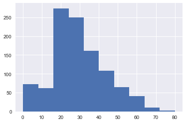

```python
# fill in null's for age
filledage=ship[ship['Age'].notnull()]
plt.hist(filledage['Age'])
```

### Total survivors vs non-survivors

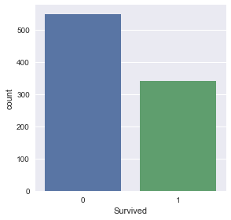

```python
sns.factorplot('Survived', data=train, kind="count");
```

### Age distribution of survivors Vs. non- survivors

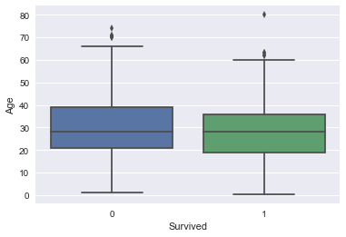

```python
y=train['Age']
x=train['Survived']
sns.boxplot(x=x,y=y)
```

### Fare distribution of survivors Vs. non- survivors

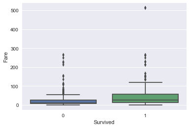

```python
y=train['Fare']
x=train['Survived']
sns.boxplot(x=x,y=y)
```

### Male and Female survivors Vs. non- survivors totals

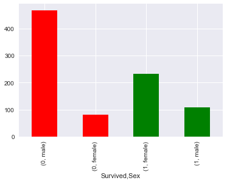

```python
grf=train.groupby('Survived')['Sex'].value_counts()
grf.plot.bar(color=['red', 'red','green','green']);
```

### Pclass survivors Vs. non- survivors totals

```python
# shows the percent of each P-class that Survived
ship.groupby('Pclass')['Survived'].mean()
```

```
Pclass
1    0.629630
2    0.472826
3    0.242363
Name: Survived, dtype: float64
```

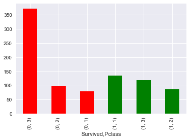

```python
grf=train.groupby('Survived')['Pclass'].value_counts()
grf.plot.bar(color=['red', 'red','red','green','green','green']);
```

```python
### Parch survivors Vs. non- survivors totals
```

```python
grf=train.groupby('Survived')['Parch'].value_counts()
grf
```

```
Survived  Parch
0         0        445
          1         53
          2         40
          4          4
          5          4
          3          2
          6          1
1         0        233
          1         65
          2         40
          3          3
          5          1
Name: Parch, dtype: int64
```

# Fill in Null Values

## Embarked null values

Check to see the different ports people embarked from

```python
ship['Embarked'].unique()
```

```
array(['S', 'C', 'Q', nan], dtype=object)
```

```python
# finding the port that is the mode
ship['Embarked'].value_counts()
```

```
S    914
C    270
Q    123
Name: Embarked, dtype: int64
```

```python
# fill all Embarked Null values with S
ship['Embarked'].fillna('S',inplace = True)
```

## Fare null values

Use the median to fill in the null values

```python
ship['Fare'].fillna(ship['Fare'].median(),inplace=True)
```

## Cabin Null Values

```python
# Creates a Deck column with just the first Letter of the Cabin string (the Deck)
ship['Deck'] = ship.Cabin.str[:1]
# Delete Cabin Column
del ship['Cabin']
```

```python
# Creates Last name column

# intialize lists
listname=[]
listtitle=[]
# loop through each Name in the Datafame
for row in ship['Name']:
    # split the name to extract the last name
    name=row.split()
    counter=0
    # loop through the name and look for the beginning of the last name indicated by a period
    for word in name:
        if '.' in word:
            break
        counter+=1
    # Using the location of the last name in the name split extract the last name
    name=name[counter:]
    # Extract the title
    title=name[0]
    # Extract the last name
    name=name[1]
    # Append the title and last name to to the lists
    listname.append(name)
    listtitle.append(title)
print len(listname)

# create new columns for last name and title we will use title later on
ship['Lname']=listname
ship['title']=listtitle
```

```
1309
```

```python
# remove extranous symbols from Lastname column
lastname=[]
# Iterate through last name column
for row in ship['Lname']:
    # look for the symbols you want to get rid of
    # Using if statments delete the extranous () symbols
    if '(' in row:
        if ')' not in row:
            name=row[1:]
            lastname.append(name)
    if '(' in row:
        if ')' in row:
            name=name[1:-1]
            lastname.append(name)
    else:
        lastname.append(row)

ship['Lname']=lastname
```

```python
# Loop to assign deck to null values using last name as search parameter
rown=0
# iterate using an indexer over every row in dataframe ship
for index, row in ship.iterrows():
    # if deck is a null value continue to the next row
    if(pd.isnull(row['Deck'])):
        continue
    else:
        # If deck is not a null value check if the passenger has relatives aboard the ship
        if row['SibSp']>0 or row['Parch']>0:
            # If they do store their last name and deck in variables
            name=row['Lname']
            deck=row['Deck']
            # Now begin looping through the Dataframe again looking for passengers with similar last names
            for index2, row in ship.iterrows():
                if row['Lname']==name:
                    if(pd.isnull(row['Deck'])):
                    # Once you find relatives and they have a null value in deck assign them the same deck
                        ship.at[index2,'Deck']=deck
    rown+=1
```

Fill the rest of the null values for deck with unkown

```python
ship['Deck'].fillna('Unkown',inplace = True)
```

## Age null Values

```python
# find the median age using the title column we create earlier
ship.groupby('title')['Age'].mean()
```

```
title
Capt.        70.000000
Col.         54.000000
Countess.    33.000000
Don.         40.000000
Dona.        39.000000
Dr.          43.571429
Jonkheer.    38.000000
Lady.        48.000000
Major.       48.500000
Master.       5.482642
Miss.        21.774238
Mlle.        24.000000
Mme.         24.000000
Mr.          32.252151
Mrs.         36.994118
Ms.          28.000000
Rev.         41.250000
Sir.         49.000000
Name: Age, dtype: float64
```

```python
# Create dictionary of titles as keys and median age as values
dic={'Capt.':70, 'Col.':54, 'Countess.':33, 'Don.':40, 'Dona.':39, 'Dr.':43.5, 'Jonkheer.':38, 'Lady.':48, 'Major.':48.5, 'Master.':5, 'Miss.':21, 'Mlle.':24, 'Mme.':24, 'Mr.':32, 'Mrs.':36, 'Ms.':28, 'Rev.':41.5, 'Sir.':49}
```

```python
# create search function that fills in age null values based on title

# iterate through the Dataframe
for index, row in ship.iterrows():
    # look for null values in the age column
    if (pd.isnull(row['Age'])):
        # Use the title dictionary to fill in the age based on the title of the passenger
        title=row['title']
        ship.at[index,'Age']=dic[title]
```

```python
# Now Bin the Ages so that we may pass them as a categorical variable to the algorithm
Agecat=[]
for index, row in ship.iterrows():
    if 0<row['Age']<15.555555:
        Agecat.append('Child')
    if 15.5555555<row['Age']<21.333333:
        Agecat.append('Young Adult')
    if 21.333333<row['Age']<49.555555:
        Agecat.append('Adult')
    if 49.5555555<row['Age']:
        Agecat.append('Elder')

ship['Age']=Agecat
```

# Feature enginering

```python
# Create column for to indicate passenger or crew member
cplist=[]

# Using the fare we can tell if someone was a crew member of a passenger
for index, row in ship.iterrows():
    if row['Fare']==0:
        name='crew'
        cplist.append(name)
    else:
        name='passenger'
        cplist.append(name)

ship['Pass/crew']=cplist
```

```python
# combine Parch and Sibsp columns
ship['familySize']=ship['Parch']+ship['SibSp']
ship.familySize.unique()
```

```
array([ 1,  0,  4,  2,  6,  5,  3,  7, 10], dtype=int64)
```

```python
# look at distribution of family sizes
```

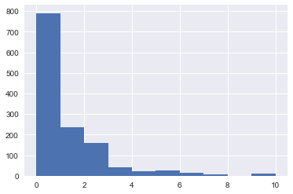

```python
plt.hist(ship['familySize'])
```

```python
# look at survival rates per family size
ship.groupby('familySize')['Survived'].mean()
```

```
familySize
0     0.303538
1     0.552795
2     0.578431
3     0.724138
4     0.200000
5     0.136364
6     0.333333
7     0.000000
10    0.000000
Name: Survived, dtype: float64
```

Based of the above survival rates bin the family sizes to create a categorical variable

```python
listfam=[]
for index, row in ship.iterrows():
    if row['familySize']==0:
        fam ='none'
        listfam.append(fam)
    elif row['familySize']<4:
        fam='small'
        listfam.append(fam)
    elif 3<row['familySize']<7:
        fam='medium'
        listfam.append(fam)
    elif row['familySize']>6:
        fam='large'
        listfam.append(fam)
ship['familySize']=listfam
```

look at survival rates per family category

```python
ship.groupby('familySize')['Survived'].mean()
```

```
familySize
large     0.000000
medium    0.204082
none      0.303538
small     0.578767
Name: Survived, dtype: float64
```

Delete any extranous columns not needed in algorithm

```python
del ship['Deck'] # deleted because there was not enough information
del ship['Lname']
del ship['SibSp'] # deleted family size captures this information
del ship['Parch'] # deleted family size captures this information
del ship['Embarked']
```

# Create dummy Variables

```python
Xy=ship.copy()
del Xy['PassengerId']
del Xy['Ticket']
del Xy['Name']
```

```python
Xy=pd.get_dummies(Xy,drop_first=True)
```

# Modeling

```python
from sklearn.cross_validation import train_test_split
```

```python
#Use legnth to split ship dataframe back into orgianl train and test dataframes
print len(train), len(test), len(ship)
NewTrain= Xy[:891]
NewTest=Xy[891:]
# delete the survived coulumn from the test datafame
del NewTest['Survived']
```

```
891 418 1309
```

```python
# Define X & y
y = NewTrain['Survived']
X =NewTrain.copy()
del X['Survived']
```

```python
#vtrain test split the data

X_train, X_test, y_train, y_test = train_test_split(X, y, test_size=.30, random_state=42)
```

# Fit models

```
1. Logistic Regression
2. Decesion Tree
3. Random Forest
4. Gradient Boosting Classifer
5. AdaBoost Classifier
```

Import the models form sklearn

```python
from sklearn.linear_model import LogisticRegression
from sklearn.ensemble import AdaBoostClassifier, GradientBoostingClassifier, RandomForestClassifier
from sklearn.tree import DecisionTreeClassifier
```

Create the models

```python
log = LogisticRegression()
tree = DecisionTreeClassifier()
forest = RandomForestClassifier()
gradient = GradientBoostingClassifier()
ada = AdaBoostClassifier()
```

fit the models

```python
l = log.fit(X_train, y_train)
t = tree.fit(X_train, y_train)
f = forest.fit(X_train, y_train)
g = gradient.fit(X_train, y_train)
a = ada.fit(X_train, y_train)
```

Use the feature importance to examine which variable best predicts survival

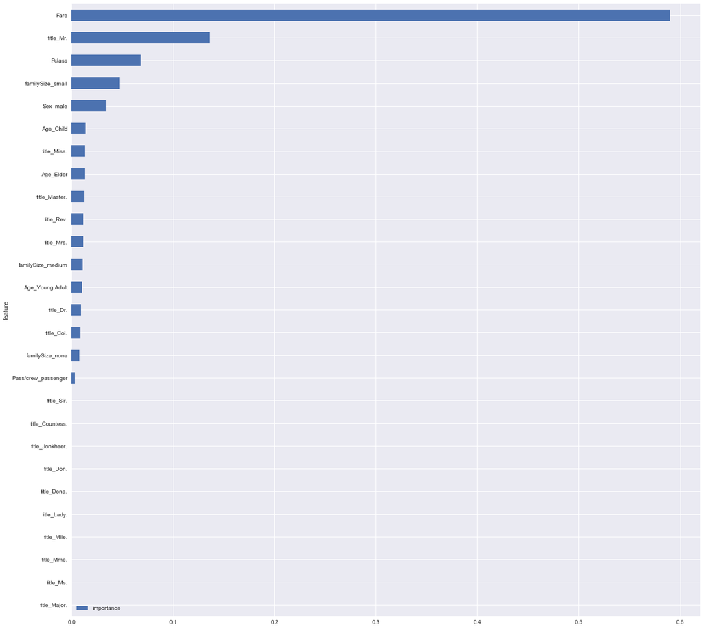

```python
features = pd.DataFrame()
features[ 'feature' ] = X.columns
features['importance'] = g.feature_importances_
features.sort_values(by=['importance'], ascending=True,inplace=True)
features.set_index('feature', inplace=True)
features.plot(kind='barh', figsize=(20,20))
```

# Evaluate the models

```python
from sklearn.metrics import accuracy_score, f1_score, mean_squared_error
```

```python
print(l.score(X_test, y_test))
print(f.score(X_test, y_test))
print(g.score(X_test, y_test))
print(a.score(X_test, y_test))
```

```
0.824626865672
0.820895522388
0.847014925373
0.809701492537
```

```python
# Use most accurate model to submit to kaggle

# using the Gradient Boosting Classifier predict the classifications and store them in a new dataframe
survivedClassify = g.predict(NewTest)
# make sure they are stored as integers for Kaggle
survivedClassify =survivedClassify.astype(int)
```

```python
# create a new data frame using the results data frame and match up the survival classification of each passenger with their IDs
results= pd.DataFrame(columns=['PassengerId','Survived'])
results['PassengerId']= test['PassengerId']
results['Survived']= survivedClassify
# Output the data frame to a csv file now it is ready to submit to kaggle
results.to_csv('results.csv',  index = False)
```